# MSstats Sample Size Estimator

Sumedh Sankhe

8/11/2020

## Introduction

`MSstats - Sample Size Estimator` is a web-based graphical user interface that provides a user-friendly way to visualize and report the results from [`MSstatsSampleSize`](https://Bioconductor.org/packages/release/bioc/html/MSstatsSampleSize.html) package

[`MSstatsSampleSize`](https://Bioconductor.org/packages/release/bioc/html/MSstatsSampleSize.html) is an open-source R package, available in Bioconductor. It allows researchers to design optimal MS-based proteomics experiments in terms of statistical power and the use of resources for biomarker discovery. In particular, `MSstatsSampleSize` uses protein-level data from a prior MS-based proteome investigation as a basis to plan future experiments with similar methodologies. The software therefore significantly contributes to the design of biological and clinical studies that involve replicates.

`MSstats - Sample Size Estimator` was created using [`R-Shiny`](https://shiny.rstudio.com/) , a Web Application Framework for R. It enables researchers without experience with R/programming to utilize the functions from MSstatsSampleSize.

## Notes:

- As a preliminary experiment, more biological replicates are preferred but a minimal of three biological replicates per condition` are required in the input dataset.
- MSstatsSampleSize uses simulation experiments to mimic the future experiments with different sample sizes. Thus, increasing the simulated sample size and the number of simulations are expected to increase the running time.

## Getting Started

The Web application follows the work-flow given below, we will walkthrough each process of the work-flow in this manual.

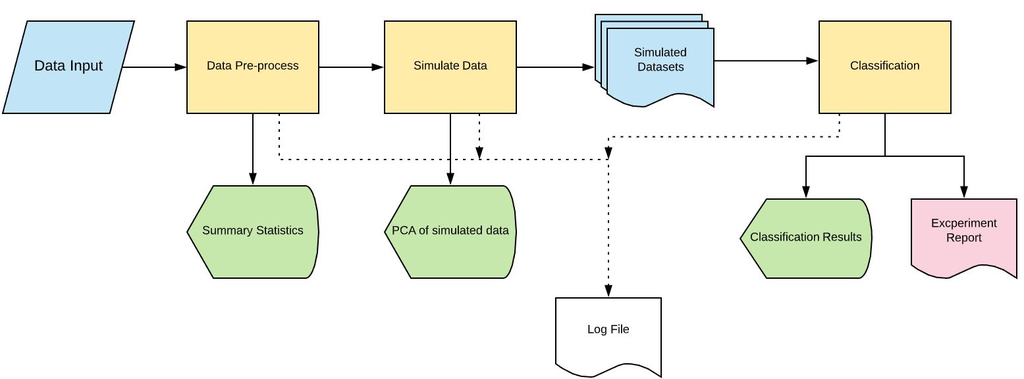

## Import Data

Navigate to the Data Import panel from the Home panel by either clicking the orange `Start` button or by clicking on `Import data` on the sidebar.  
The Data Import Wizard lets the user upload protein abundance and annotation data of their choice, alternatively an example dataset from the `MSstatsSampleSize` package can be loaded to explore the web application. A snapshot of the data that is available within the web application is given below.

```
## Sample protein abundance data, with rows as proteins and columns as biorepicates
```

```
##      111_data2 112_data2 114_data2 115_data2 117_data2
## AFM  18.125305  18.64349 17.786586  18.62598 18.097136
## AHSG 19.128721  19.11689 19.286422  19.55758 19.344060
## AIAG 14.622719  14.67904 14.573159  14.63815 14.721183
## AOC3  9.632189  10.11125  9.206763  10.16800  9.684437
## APOH 17.426479  17.43132 17.075589  17.56990 17.487654
## ATRN 15.686383  15.87728 15.363577  15.94339 15.797377
```

```
## Sample annotation data
```

```
##    BioReplicate Condition Run
## 88 "111_data2"  "control" "111_data2"
## 89 "112_data2"  "control" "112_data2"
## 90 "114_data2"  "control" "114_data2"
## 91 "115_data2"  "control" "115_data2"
## 92 "117_data2"  "control" "117_data2"
## 93 "118_data2"  "control" "118_data2"
```

To upload, select `Protein-level quantification` in the **Select Data Type** drop down menu. When presented with the options to upload files, please upload Protein abundance and Annotation files to requested slots as shown in the figures below.

*A word of caution :* The data uploaded to the application is expected to be transformed by one of the several converters available in the MSstats package. The data is expected to be log transformed.

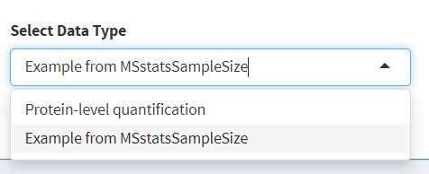

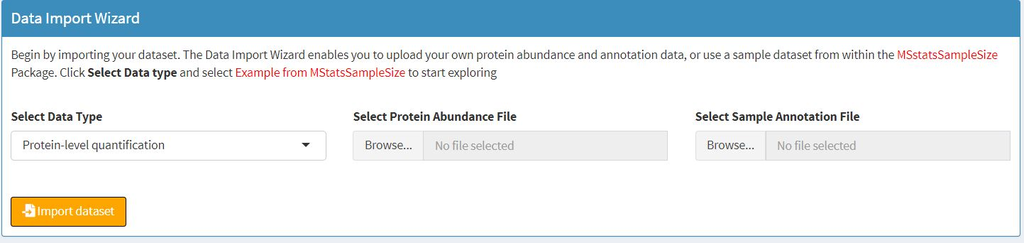

## Simulate Datasets

Simulating datasets with the ability to reproduce the simulation experiment is provided by this shiny application. Various parameters which are required for the simulation can be tuned and adjusted through this panel.

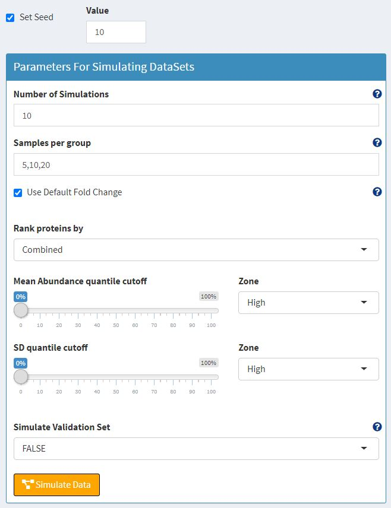

**Set Seed:** The set seed option, when selected allows the user to specify a seed value. This enables reproducibility in the data simulation process as well as the dataset classification process.

**Number of Simulations:** This parameter lets the user decide the number datasets that need to be simulated.

**Samples per group:** Defines the number of samples per condition existing in the input dataset need to be simulated, a minimum of 3 samples per group need to be provided to create a viable dataset.

**Rank proteins by:** Proteins can be selected in a multitude of ways, capabilities to selected proteins are provided by either selecting them based of their Mean abundances, Standard deviations or a combined effect of both.

**Mean Abundance quantile and SD cutoffs:** The mean abundance cutoff and standard deviations (SD) cutoff values are quantile values above or at or below which proteins needs to be selected for simulating the datasets. The Zone dropdown lets the user select High or Low values to be selected.

**Simulate Validation Set:** This toggle option lets the user decide if additional data needs to be simulated for validating the results of the model training that occurs in the classification phase of the application.

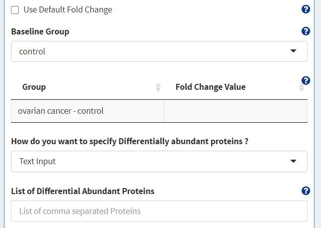

**Validation Samples per group:** This input allows the users to specify the number of validation samples to simulate per group. By default the entire input dataset is considered as a validation set for the simulated datasets.

**Use Default Fold Change:** This toggle lets the user control the fold change values between the different groups presented in the input data. The default selection for this is to use the default fold change from the data.

**Baseline Group:** Users can define the baseline group according to which the fold changes are identified, the table following this option lets the user define numeric values for the different fold changes.  
**Specifying Deferentially abundant proteins:** This feature lets the user control the protein selection process, pre-defining the deferentially abundant proteins by either providing a comma separated text value in the typing area provided, alternatively a text file with comma separated values can be uploaded to the interface.

**Simulate Data :** The orange simulate data button begins the simulation of the data considering all the provided parameters, the Mean and Standard deviation plot is highlighted, the proteins belonging to the highlighted region have been selected for the simulation process. The selection process depends on how the proteins have been ranked and what their quantile cutoff are.

PCA analysis of the simulated datasets is carried out and visualized. These plots are downloadable and can be used for further research.

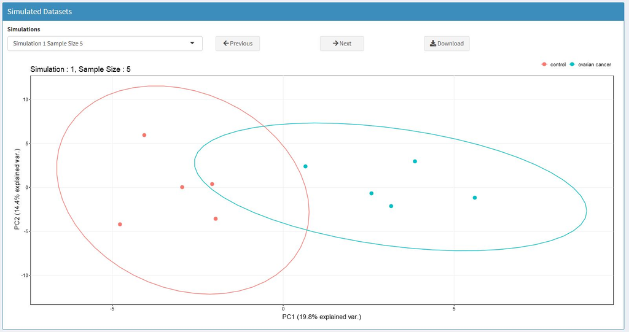

## Plan Experiment

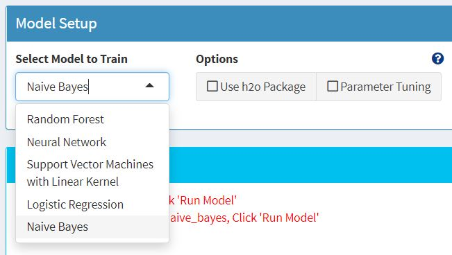

The Shiny application has capabilities to use 5 different classification algorithms to identify the optimal sample size from the simulated datasets. The classification algorithms are listed as below:

- Random Forest
- Neural Networks
- Support Vector Machine with Linear Kernel
- Logistic Regression
- Naive Bayes

The application provides features to use h2o to train models with extremely large number of predictors, although this feature is currently in testing phase some of its caveats are as follows:

- Hardware requirement for h2o may not always be met on a user machine
- Setting up a cloud based h2o machine for public use is not be feasible, and data security/privacy concerns may discourage users

Selecting the required classifier and hitting the **Run Model** button runs the classification algorithm on the simulated datasets. The machine learning process selects the top 10 features on every simulated datasets to train the classifiers. An optimal sample size is suggested after the classifiers are trained, the optimal sample size is highlighted in the Accuracy plot. The protein importance plots highlights the most recurring proteins that have been selected for model training amongst all the datasets.

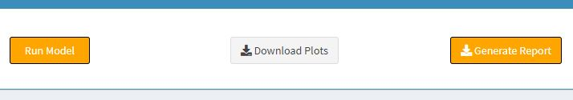

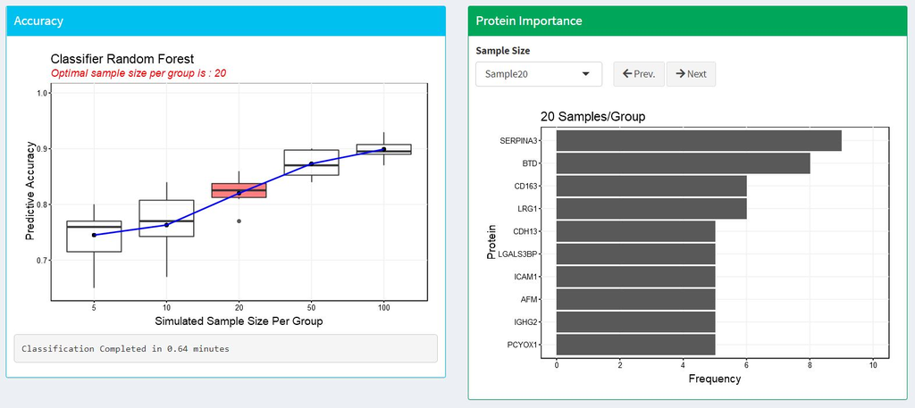

A pdf report of the entire experiment that was carried out can be generated via the User interface by clicking the **Generate Report** button. The report contains the optimal solution that was identified, the plots that visualize this information. The report also contains the details of all the parameters that were used to simulate the datasets and chunks of code which can help the researcher reproduce the experiment on their own machines if required.